# CS 329E Data Visualization R Project 1

Nur Syairah Mohd Ridzuan, Madeline Packard, Arthur DeVitalis

February 4th, 2015

In this project, we will go through the steps necessary to reproduce visualizations from data frames pulled from Oracle.

### Pulling Data Frames

Here, we pull four different data frames from the given orders schema. Notice how each data frame is saved, and then called with the head() function.

```r
source("../01 Data/created_dataframe.R", echo = TRUE)
```

```
##
## > library(RCurl)
##
## > customer_df <- data.frame(eval(parse(text = substring(getURL(URLencode("http://129.152.144.84:5001/rest/native/?query=\"SELECT * FROM customers\""), .... [TRUNCATED]
##
## > items_df <- data.frame(eval(parse(text = substring(getURL(URLencode("http://129.152.144.84:5001/rest/native/?query=\"SELECT * FROM items\""),
## +     .... [TRUNCATED]
##
## > order_details_df <- data.frame(eval(parse(text = substring(getURL(URLencode("http://129.152.144.84:5001/rest/native/?query=\"SELECT * FROM order_det .... [TRUNCATED]
##
## > orders_df <- data.frame(eval(parse(text = substring(getURL(URLencode("http://129.152.144.84:5001/rest/native/?query=\"SELECT * FROM orders\""),
## +   .... [TRUNCATED]
```

```r
head(customer_df)
```

```
##   CUSTOMER_ID CUSTOMER_FIRST_NAME CUSTOMER_LAST_NAME      CUSTOMER_ADDRESS
## 1           1               Korah             Blanca       1555 W Lane Ave
## 2           2                Yash            Randall 11 E Rancho Madera Rd
## 3           3           Johnathon          Millerton        60 Madison Ave
## 4           4             Mikayla             Damion      2021 K Street Nw
## 5           5             Kendall              Mayte 4775 E Miami River Rd
## 6           6             Kaitlin           Hostlery 3250 Spring Grove Ave
##   CUSTOMER_CITY CUSTOMER_STATE CUSTOMER_ZIP CUSTOMER_PHONE CUSTOMER_FAX
## 1      Columbus             OH        43221     6145554432   6145553920
## 2       Madison             WI        53707     2095551205   2095552262
## 3      New York             NY        10010     2125554800         NULL
## 4    Washington             DC        20006     2025555561         NULL
## 5        Cleves             OH        45002     5135553024         NULL
## 6    Cincinnati             OH        45225     8005552128   8005552640
```

```r
head(items_df)
```

```
##   ITEM_ID                                       TITLE
## 1       1                            Umami In Concert
## 2       2                             Race Car Sounds
## 3       3                       No Rest For The Weary
## 4       4 More Songs About Structures and Comestibles
## 5       5               On The Road With Burt Ruggles
## 6       6                            No Fixed Address
##                  ARTIST UNIT_PRICE
## 1                 Umami         17
## 2         The Ubernerds         13
## 3 No Rest For The Weary         16
## 4 No Rest For The Weary         17
## 5          Burt Ruggles         17
## 6 Sewed the Vest Pocket         16
```

```r
head(order_details_df)
```

```
##   ORDER_ID ITEM_ID ORDER_QTY
## 1      381       1         1
## 2      601       9         1
## 3      442       1         1
## 4      523       9         1
## 5      630       5         1
## 6      778       1         1
```

```r
head(orders_df)
```

```
##   ORDER_ID CUSTOMER_ID          ORDER_DATE        SHIPPED_DATE
## 1       19           1 2012-10-23 00:00:00 2012-10-28 00:00:00
## 2       29           8 2012-11-05 00:00:00 2012-11-11 00:00:00
## 3       32          11 2012-11-10 00:00:00 2012-11-13 00:00:00
## 4       45           2 2012-11-25 00:00:00 2012-11-30 00:00:00
## 5       70          10 2012-12-28 00:00:00 2013-01-07 00:00:00
## 6       89          22 2013-01-20 00:00:00 2013-01-22 00:00:00
```

### Visual Representations

We can use ggplot to display the dataframes in various kinds of visualizations.

```
##
## > library(ggplot2)
##
## > ggplot(customer_df, aes(x = CUSTOMER_STATE, y = CUSTOMER_CITY)) +
## +     geom_point()
```

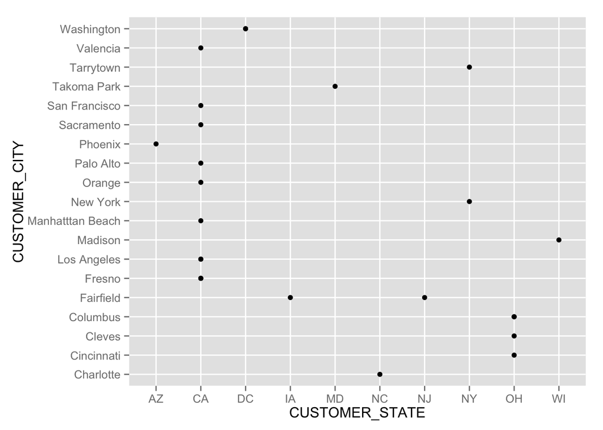

```r
source("../02 Visualizations/customerdf_plot.R", echo = TRUE)
```

This graph displays the possibility that city and state has many-to-many relationship due to the existence of Fairfield in both IA and NJ.

```
##
## > library(ggplot2)
##
## > ggplot(items_df, aes(x = ARTIST, y = UNIT_PRICE)) +
## +     geom_point()
```

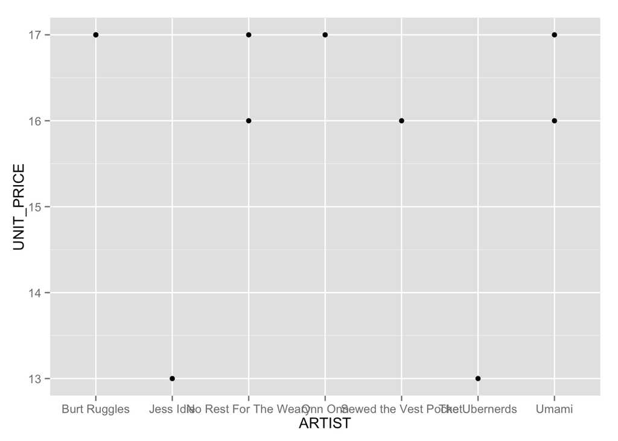

```r
source("../02 Visualizations/itemsdf_plot.R", echo = TRUE)
```

From this graph, it can be inferred that the competitive unit price for artists to sell their albums falls between 16 and 17 dollars per album.

```
##
## > library(ggplot2)
##
## > ggplot(order_details_df) + geom_histogram(aes(x = ITEM_ID),
## +     binwidth = 1, colour = "purple", fill = "white")
```

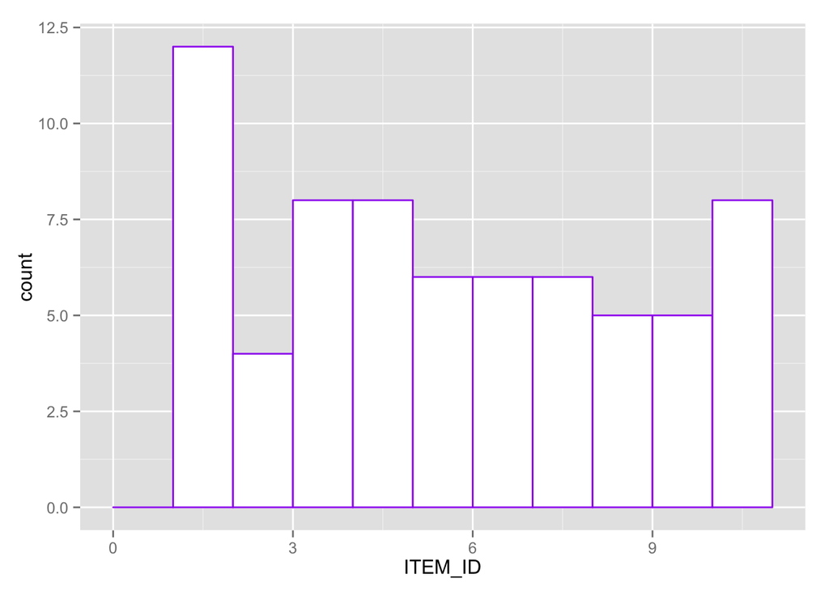

```r
source("../02 Visualizations/orderdetailsdf_plot.R", echo = TRUE)
```

This histogram indicates the popularity of each item sold with the quantity shown on y-axis. It can be inferred that the album with item_id 1 is the highest selling product.

```
##
## > library(ggplot2)
##
## > ggplot(orders_df, aes(x = CUSTOMER_ID, y = ORDER_ID)) +
## +     geom_point() + facet_wrap(~CUSTOMER_ID)
```

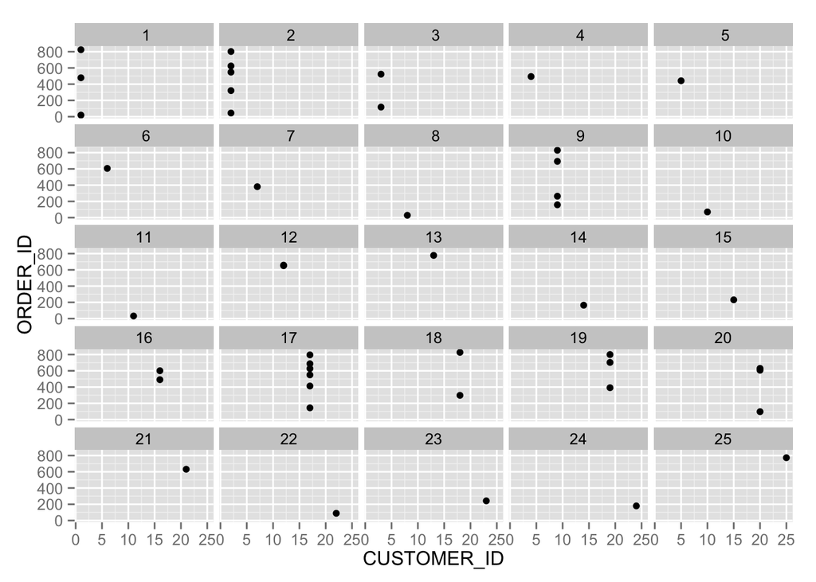

```r
source("../02 Visualizations/ordersdf_plot.R", echo = TRUE)
```

This graph may indicate the customer loyalty based on the frequency of each customer purchasing albums from this company.

## Reproducing the graphs displayed in step 10

First, we need to combine all the data frames above. This is done by inserting the following SQL command ‘select * from orders o join customers c on o.customer_id = c.customer_id join order_details d on o.order_id = d.order_id join items i on d.item_id = i.item_id’ inside RestfulREL call. The resulting call is as follows:

```r
source("../01 Data/allcombine_df.R", echo = TRUE)
```

```
##
## > require(RCurl)
##
## > combine_df <- data.frame(eval(parse(text = substring(getURL(URLencode("http://129.152.144.84:5001/rest/native/?query=\"select * from orders o join c .... [TRUNCATED]
```

Create a subset of `combine_df` containing the following vectors: ORDER DATE, SHIPPED DATE, UNIT PRICE, CUSTOMER_STATE

```r
source("../01 Data/subset_unitprice.R", echo = TRUE)
```

```
##
## > shipped_byunitprice <- combine_df[, c("ORDER_DATE",
## +     "SHIPPED_DATE", "UNIT_PRICE", "CUSTOMER_STATE")]
```

```r
#view the new data frame created from the subset
head(shipped_byunitprice)
```

```
##            ORDER_DATE        SHIPPED_DATE UNIT_PRICE CUSTOMER_STATE
## 1 2014-03-23 00:00:00 2014-04-03 00:00:00         17             CA
## 2 2013-08-18 00:00:00 2013-09-22 00:00:00         17             NY
## 3 2013-06-24 00:00:00 2013-07-06 00:00:00         17             CA
## 4 2014-08-02 00:00:00                null         17             CA
## 5 2012-12-28 00:00:00 2013-01-07 00:00:00         17             CA
## 6 2014-07-21 00:00:00 2014-07-28 00:00:00         17             AZ
```

Notice that in `shipped_byunitprice` data frame, ORDER DATE and SHIPPED DATE contain details that we do not need to create the graph, which are the time of order as well as the time in which the item got shipped. In order to eliminate these details, reformat ORDER DATE and SHIPPED DATE using `as.Date` function. This can be done when creating a visual representation using `ggplot2` package:

```r
source("../02 Visualizations/shipped_byunitprice.R", echo = TRUE)
```

```
##
## > ggplot(shipped_byunitprice, aes(x = as.Date(ORDER_DATE,
## +     "%Y-%m-%d"), y = as.Date(SHIPPED_DATE, "%Y-%m-%d"))) + geom_point(aes(color = as.fact .... [TRUNCATED]
```

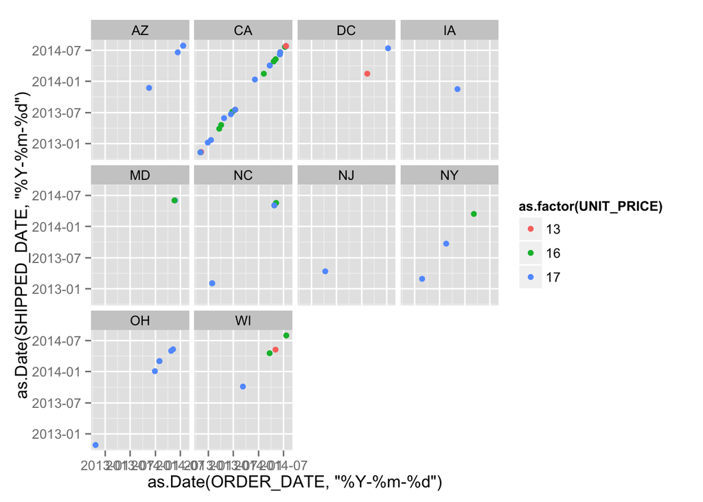

Repeat the steps to produce the latter two graphs.

```r
source("../01 Data/subset_title.R", echo = TRUE)
```

```
##
## > shipped_bytitle <- combine_df[, c("ORDER_DATE", "SHIPPED_DATE",
## +     "TITLE", "CUSTOMER_STATE")]
```

```r
head(shipped_bytitle)
```

```
##            ORDER_DATE        SHIPPED_DATE            TITLE CUSTOMER_STATE
## 1 2014-03-23 00:00:00 2014-04-03 00:00:00 Umami In Concert             CA
## 2 2013-08-18 00:00:00 2013-09-22 00:00:00 Umami In Concert             NY
## 3 2013-06-24 00:00:00 2013-07-06 00:00:00 Umami In Concert             CA
## 4 2014-08-02 00:00:00                null Umami In Concert             CA
## 5 2012-12-28 00:00:00 2013-01-07 00:00:00 Umami In Concert             CA
## 6 2014-07-21 00:00:00 2014-07-28 00:00:00 Umami In Concert             AZ
```

```r
source("../02 Visualizations/shipped_bytitle.R", echo = TRUE)
```

```
##
## > ggplot(shipped_bytitle, aes(x = as.Date(ORDER_DATE,
## +     "%Y-%m-%d"), y = as.Date(SHIPPED_DATE, "%Y-%m-%d"))) + geom_point(aes(color = as.factor(T .... [TRUNCATED]
```

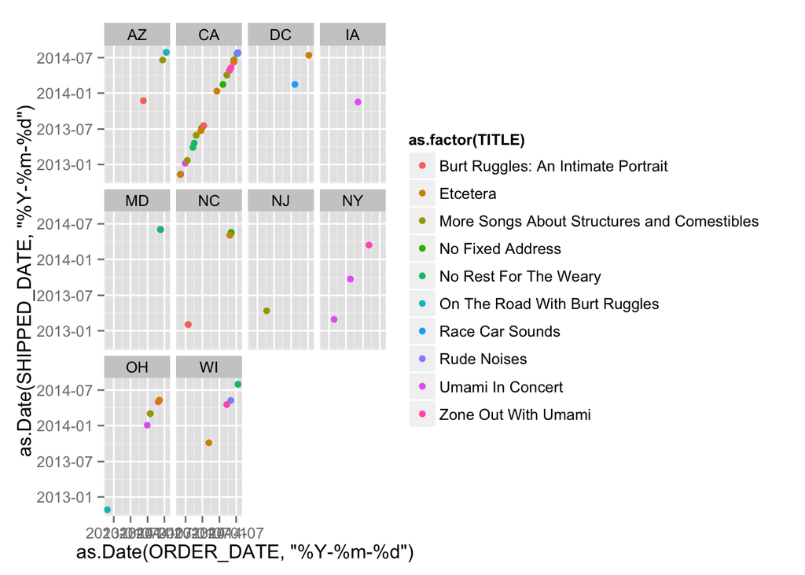

```r
source("../01 Data/subset_artist.R", echo = TRUE)
```

```
##
## > shipped_byartist <- combine_df[, c("ORDER_DATE", "SHIPPED_DATE",
## +     "ARTIST", "CUSTOMER_STATE")]
```

```r
head(shipped_byartist)
```

```
##            ORDER_DATE        SHIPPED_DATE ARTIST CUSTOMER_STATE
## 1 2014-03-23 00:00:00 2014-04-03 00:00:00  Umami             CA
## 2 2013-08-18 00:00:00 2013-09-22 00:00:00  Umami             NY
## 3 2013-06-24 00:00:00 2013-07-06 00:00:00  Umami             CA
## 4 2014-08-02 00:00:00                null  Umami             CA
## 5 2012-12-28 00:00:00 2013-01-07 00:00:00  Umami             CA
## 6 2014-07-21 00:00:00 2014-07-28 00:00:00  Umami             AZ
```

```r
source("../02 Visualizations/shipped_byartist.R", echo = TRUE)
```

```
##
## > ggplot(shipped_byartist, aes(x = as.Date(ORDER_DATE,
## +     "%Y-%m-%d"), y = as.Date(SHIPPED_DATE, "%Y-%m-%d"))) + geom_point(aes(color = as.factor( .... [TRUNCATED]
```

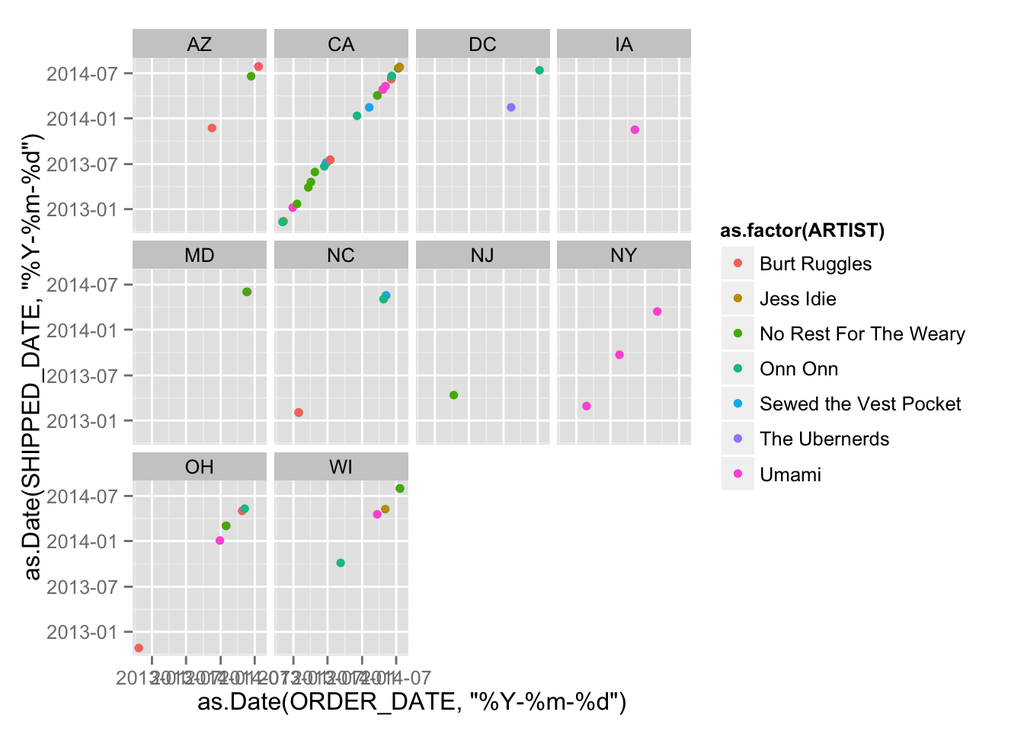